# Skills for Analysis Assignment 9

GSD SES 5394

Spring 2022

# Overview

The following skills will be useful for Analysis Assignment 9. This is not a complete list of everything you will need to do to complete the assignment; but it includes an overview of skills that you will not have encountered in prior assignments.

# Required packages

The skills in this tutorial draw on the here package, the tidyverse package, and the sf package, which are all familiar to you now.

```r
library(here)
library(tidyverse)
library(sf)
library(knitr)
library(kableExtra)
library(survey)
library(srvyr)
```

# Calculating cost variables

The model we’ll be applying has coefficients for the cost of driving and the cost of transit.

## Transit fare per unlinked trip

The National Transit Database includes information on the total annual fare revenue for each transit agency and the total number of annual unlinked trips. The easiest way to grab that data for an individual transit agency is to search for the transit agency profile [here](https://www.transit.dot.gov/ntd/transit-agency-profiles).

Here’s what the one for Niagara Frontier Transportation Authority (the agency serving Buffalo) looks like:

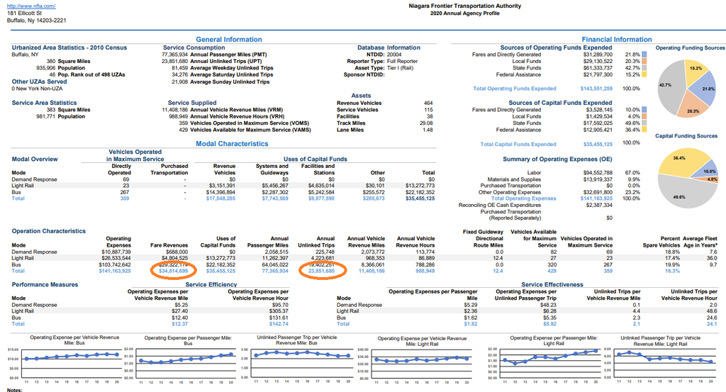

You can see that the annual fare revenue is $34,814,699 and there were 23,851,680 annual unlinked trips, for an average fare per unlinked trip of $1.46 per unlinked trip. Note that this is probably lower than the posted fare due to various discounts, transfer policies, and the use of transit passes.

```r
cost_per_ride <- 34814699 / 23851680

cost_per_ride
```

```
## [1] 1.459633
```

## Driving cost per minute

We can use NHTS data to estimate the total annual time spent driving and total annual fuel expenditures across the study area.

We’ll need the trips file and the vehicles file. In the trips file, I only want trips where there respondent was the driver. In both files, I only want to include households in Buffalo (GEOID is 15380)

```r
temp <- tempfile()
download.file("https://nhts.ornl.gov/assets/2016/download/csv.zip", temp)

vehs <- read_csv(unz(temp, "vehpub.csv"),
                 show_col_types = FALSE) %>%
  filter(HH_CBSA == "15380")

trips <- read_csv(unz(temp, "trippub.csv"),
                      show_col_types = FALSE) %>%
  filter(HH_CBSA == "15380")

car_trips <- trips %>%
  filter(PSGR_FLG == "02")

unlink(temp)
```

And we’ll need to create a survey object for both of those tables. Note that the trip weights variable is set for estimating annual trips.

```r
car_trips_svy <- car_trips %>%
  as_survey(weights = WTTRDFIN)

veh_svy <- vehs %>%
  as_survey(weights = WTHHFIN)
```

Now we can calculate the total annual time spend driving cars and the total fuel expenditure across the region.

```r
total_time <- car_trips_svy %>%
  summarise(total_time = survey_total(TRVLCMIN))

kable(total_time, format.args = list(big.mark = ",",
                                     scientific = FALSE))
```

| total_time | total_time_se |
| --- | --- |
| 13,185,044,853 | 558,729,418 |

Households in Buffalo spend a total of about 13 billion minutes driving in cars annually. Since the region’s population is just over 1 million, that’s around 13 thousand annual minutes per person or 36 daily minutes per person.

```r
total_gas_cost <- veh_svy %>%
  summarise(total_cost = survey_total(GSTOTCST))

kable(total_gas_cost, format.args = list(big.mark = ","))
```

| total_cost | total_cost_se |
| --- | --- |
| 1,002,168,527 | 76,828,735 |

Households in Buffalo spend a total of about $1 billion dollars on gasoline annually. Since the population of the study area is just over 1 million people, that’s about $1000 per person per year or $2.70 per person per day.

```r
cost_per_minute <- total_gas_cost$total_cost[1] / total_time$total_time[1]

cost_per_minute
```

```
## [1] 0.07600797
```

Buffalo households spend about 7.6 cents per minute to operate a car.

## Costs per trip

First I’ll load the skims I generated in Assignment 4.

```r
skims <- here("existing",
              "data",
              "skims.csv") %>%
  read_csv(show_col_types = FALSE)

head(skims, 5) %>%
  kable() %>%
  kable_styling() %>%
  scroll_box(width = "500px", height = "320px")
```

| fromId | toId | transit_time | access_time | wait_time | ride_time | transfer_time | egress_time | combined_time | routes | n_rides | car_time | walk_time | bike_time | min_time | F_HBW | F_HBO | F_NHB | HBO_flow | total_time |
| --- | --- | --- | --- | --- | --- | --- | --- | --- | --- | --- | --- | --- | --- | --- | --- | --- | --- | --- | --- |
| 36029016700 | 36029006901 | 65 | 12.9 | 19.6 | 28.7 | 0.0 | 4.1 | 65.2 | 2\|3 | 2 | 11 | NA | 88 | 11 | 0.1269272 | 0.0000564 | 0.0003178 | 1 | 11 |
| 36029016700 | 36029012901 | 77 | 11.4 | 29.4 | 29.7 | 1.9 | 5.5 | 77.8 | 19\|14 | 2 | 13 | NA | NA | 13 | 0.0998417 | 0.0000278 | 0.0001807 | 13 | 169 |
| 36029016700 | 36029004900 | 90 | 11.5 | 14.6 | 41.1 | 2.5 | 20.8 | 90.4 | 19\|5 | 2 | 18 | NA | 108 | 18 | 0.0573916 | 0.0000069 | 0.0000599 | 0 | 0 |
| 36029016700 | 36029001600 | 55 | 12.9 | 10.7 | 6.5 | 0.0 | 25.6 | 55.6 | 2 | 1 | 7 | 69 | 50 | 7 | 0.2176662 | 0.0003696 | 0.0014589 | 26 | 182 |
| 36029016700 | 36029007700 | 113 | 12.9 | 28.6 | 56.7 | 0.8 | 14.7 | 113.7 | 2\|25 | 2 | 24 | NA | NA | 24 | 0.0310996 | 0.0000020 | 0.0000225 | 0 | 0 |

```r
skims <- skims %>%
  mutate(drive_cost = car_time * cost_per_minute) %>%
  mutate(transit_cost = n_rides * cost_per_ride)
```

If someone carpools, they can split the cost of driving among all vehicle occupants. Table 4.16 of NCHRP 716 indicates that, for HBW trips, the average vehicle occupance of 2+ carpools is 2.42, so we’ll divide the cost of driving by 2.42 to get the cost of carpooling.

```r
skims <- skims %>%
  mutate(carpool_cost = drive_cost / 2.42)
```

# Estimate existing mode shares

We’ll be calibrating our mode choice model to the existing regional mode shares, so we’ll need to calculate the overall mode share for each of our three trip purposes

Note that I’m grouping car, truck, van, SUV, golfcart/segway, RV (including both mobile homes and snowmobiles), and motorcycle/moped all as “car”. You might choose to group things differently. The hard-to-classify modes are also fairly infrequent, so moving them among categories won’t change your result very much.

```r
trips <- trips %>%
  mutate(home_based = case_when(WHYTO == "01" ~ TRUE,
                                WHYTO == "02" ~ TRUE,
                                WHYFROM == "01" ~ TRUE,
                                WHYFROM == "02" ~ TRUE,
                                TRUE ~ FALSE)) %>%
  mutate(work = ifelse(WHYTO == "03" | WHYFROM == "03", TRUE, FALSE)) %>%
  mutate(purpose = case_when(home_based & work ~ "HBW",
                            home_based ~ "HBO",
                            TRUE ~ "NHB")) %>%
  mutate(mode = case_when(TRPTRANS == "01" ~ "walk",
                          TRPTRANS == "02" ~ "bike",
                          TRPTRANS == "03" & NUMONTRP > 1 ~ "HOV",
                          TRPTRANS == "04" & NUMONTRP > 1 ~ "HOV",
                          TRPTRANS == "05" & NUMONTRP > 1 ~ "HOV",
                          TRPTRANS == "06" & NUMONTRP > 1 ~ "HOV",
                          TRPTRANS == "08" & NUMONTRP > 1 ~ "HOV",
                          TRPTRANS == "17" & NUMONTRP > 1 ~ "HOV",
                          TRPTRANS == "18" & NUMONTRP > 1 ~ "HOV",
                          TRPTRANS == "03" ~ "SOV",
                          TRPTRANS == "04" ~ "SOV",
                          TRPTRANS == "05" ~ "SOV",
                          TRPTRANS == "06" ~ "SOV",
                          TRPTRANS == "08" ~ "SOV",
                          TRPTRANS == "17" ~ "SOV",
                          TRPTRANS == "18" ~ "SOV",
                          TRPTRANS == "10" ~ "transit",
                          TRPTRANS == "11" ~ "transit",
                          TRPTRANS == "12" ~ "transit",
                          TRPTRANS == "13" ~ "transit",
                          TRPTRANS == "16" ~ "transit",
                          TRUE ~ "other")) %>%
  filter(mode != "other")
```

Now I can create a survey object and use it to generate the number of trips by mode

```r
trips_svy <- trips %>%
  as_survey(weights = WTTRDFIN)

mode_by_purpose <- trips_svy %>%
  group_by(purpose, mode) %>%
  survey_tally() %>%
  select(-n_se) %>%
  pivot_wider(names_from = mode,
              values_from = n,
              names_prefix = "n_",) %>%
  mutate(n_trips = n_bike + n_SOV + n_HOV + n_transit + n_walk) %>%
  mutate(pct_bike = n_bike / n_trips) %>%
  mutate(pct_SOV = n_SOV / n_trips) %>%
  mutate(pct_HOV = n_HOV / n_trips) %>%
  mutate(pct_walk = n_walk / n_trips) %>%
  mutate(pct_transit = n_transit / n_trips) %>%
  select(purpose, pct_bike, pct_SOV, pct_HOV, pct_transit, pct_walk)

mode_by_purpose
```

```
## # A tibble: 3 x 6
## # Groups:   purpose [3]
##   purpose pct_bike pct_SOV pct_HOV pct_transit pct_walk
##   <chr>      <dbl>   <dbl>   <dbl>       <dbl>    <dbl>
## 1 HBO      0.0106    0.301   0.445      0.0999   0.144
## 2 HBW      0.0118    0.745   0.142      0.0536   0.0476
## 3 NHB      0.00662   0.402   0.436      0.0527   0.103
```

# Select a model

Without detailed origin-destination data (which regional travel surveys do collect, but don’t release publicly), we can’t estimate our own mode choice model, so you’ll select one from NCHRP 716.

## HBW mode choice models from NCHPR 716

For home-based work trips, you have the following 9 models to select from:

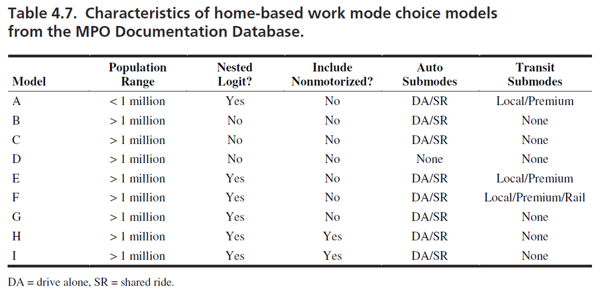

And here are the model coefficients for those:

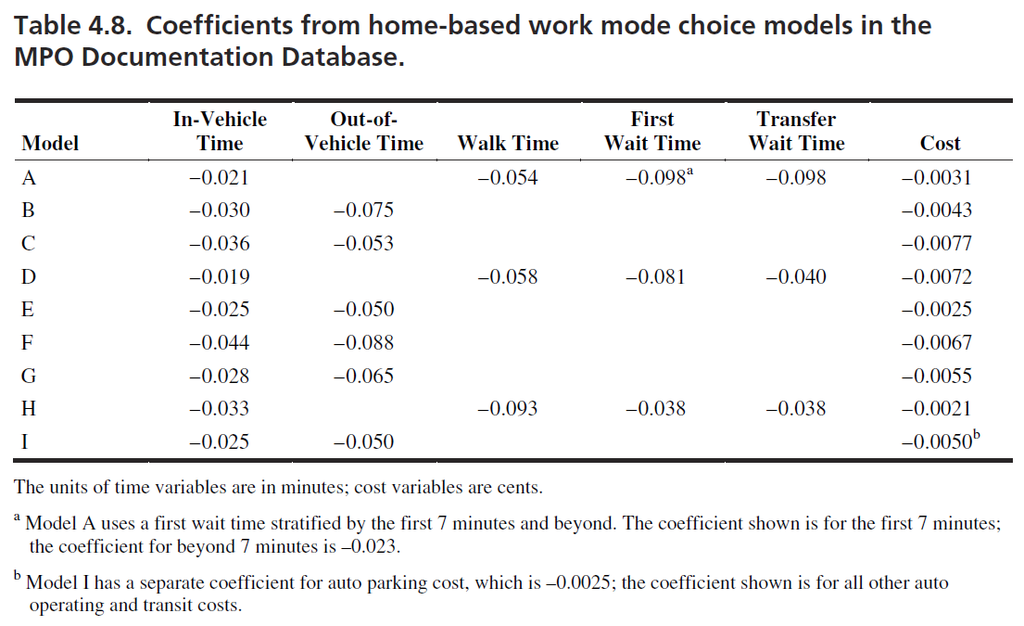

All teams are working on study areas with more than 1 million residents, so you should *not* select model A. If you are including non-motorized modes in your model, you should select model H or model I. You will find it useful to make a distinction between shared rides (carpooling) and driving alone, but you most of you probably don’t need to make a distinction between local, premium, and rail service, so if you aren’t including non-motorized modes, I recommend choosing model B, C, or G.

## HBO mode choice models from NCHPR 716

For home-based other trips, you have the following 8 models to select from:

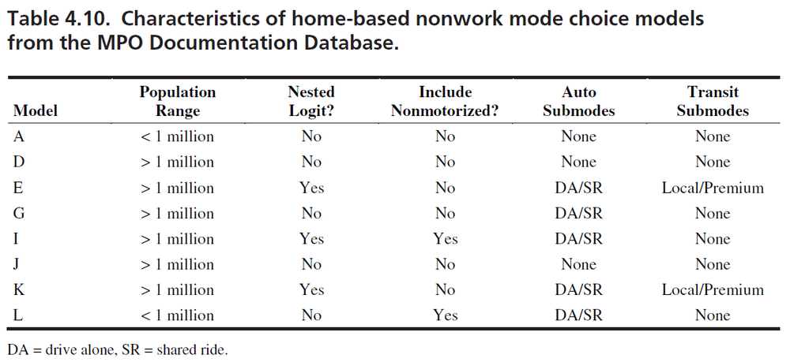

And here are the model coefficients for those:

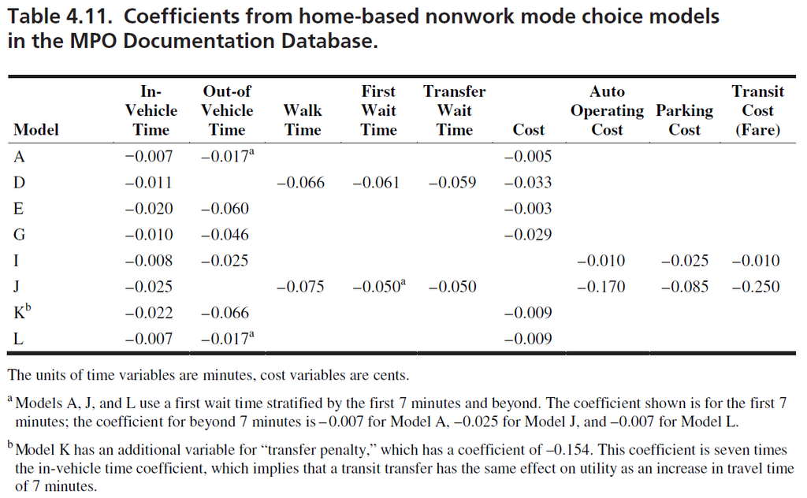

Again, all teams are working on study areas with more than 1 million residents, so you should *not* select model A or L. If you are including non-motorized modes in your model, you should select model I.

If you aren’t including non-motorized modes, G or J might be reasonable. Note that neither is a nested model, although G does include SOVs and HOVs as separate modes.

## NHB mode choice models from NCHPR 716

And for non-home-based trips, you have the following 11 models to select from:

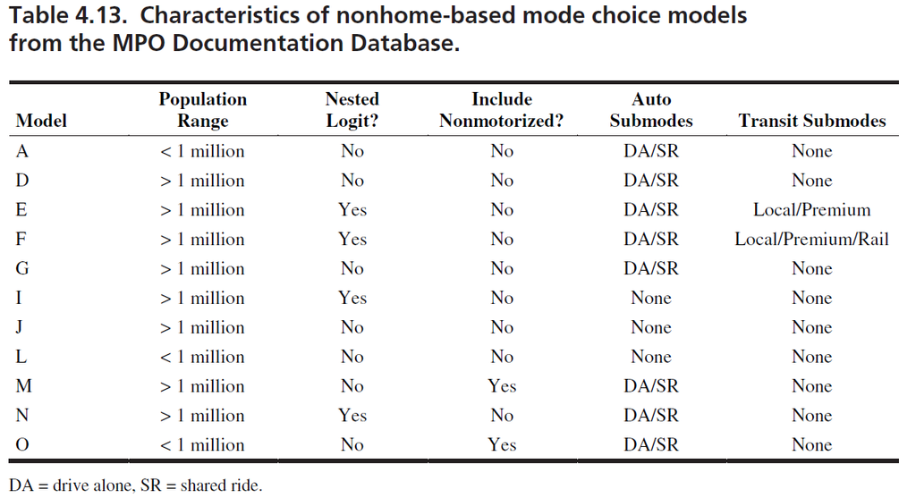

And here are the model coefficients for those:

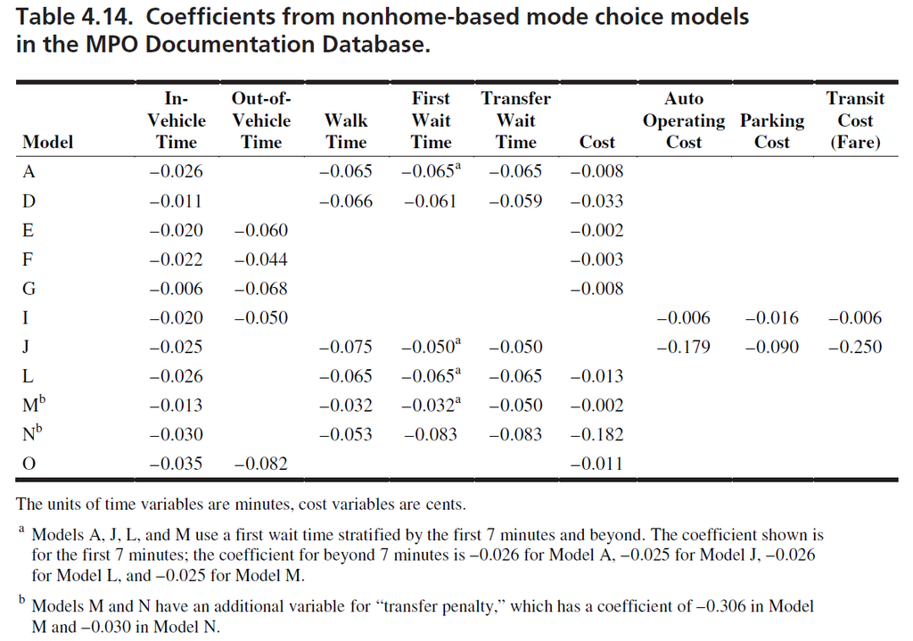

Again, all teams are working on study areas with more than 1 million residents, so you should *not* select model A, L, or O. If you are including non-motorized modes in your model, you might select model M. If you aren’t including non-motorized modes, N looks be reasonable (do pay attention to the footnotes).

# Apply a selected mode-choice model

In this example, I’ll demonstrate how I would apply Model I to estimate the mode shares for HBO trips.

## Calculate mode-specific constants

None of the tables from NCHRP provide mode-specific constants, so we’ll use the overall log-odds for each mode as an initial value, and then calibrate that value as needed.

```r
SOV_share_HBO <- mode_by_purpose$pct_SOV[mode_by_purpose$purpose == "HBO"]
HOV_share_HBO <- mode_by_purpose$pct_HOV[mode_by_purpose$purpose == "HBO"]
transit_share_HBO <- mode_by_purpose$pct_transit[mode_by_purpose$purpose == "HBO"]
walk_share_HBO <- mode_by_purpose$pct_walk[mode_by_purpose$purpose == "HBO"]
bike_share_HBO <- mode_by_purpose$pct_bike[mode_by_purpose$purpose == "HBO"]

SOV_const_HBO <- log(SOV_share_HBO / (1 - SOV_share_HBO))
HOV_const_HBO <- log(HOV_share_HBO / (1 - HOV_share_HBO))
transit_const_HBO <- log(transit_share_HBO / (1 - transit_share_HBO))
walk_const_HBO <- log(walk_share_HBO / (1 - walk_share_HBO))
bike_const_HBO <- log(bike_share_HBO / (1 - bike_share_HBO))
```

## Estimate utility of each mode

Now I’ll apply the model from NCHRP Table 4.11 to estimate the utility of each mode based on the coefficients from NCHRP Table 4.11. I’m going to assume the cost of parking is zero for all zones.

This is a nested model. The total utility for a nest with m modes in the nest is given by the logsum:

$U_{nest} = log{\sum\limits_{m} e^{U_{m}}}$

```r
skims <- skims %>%
  mutate(utility_transit_HBO = transit_const_HBO +
                               ride_time * -0.008  +
                               (access_time +
                                 egress_time +
                                 wait_time +
                                 transfer_time) * -0.025 +
                               transit_cost * -0.01,
         utility_SOV_HBO = SOV_const_HBO +
                           car_time * -0.008 +
                           drive_cost * -0.01,
         utility_HOV_HBO = HOV_const_HBO +
                           car_time * -0.008 +
                           carpool_cost * -0.01,
         utility_walk_HBO = walk_const_HBO +
                            walk_time * -0.025,
         utility_bike_HBO = bike_const_HBO +
                            bike_time * -0.025) %>%
  mutate(exp_u_walk_HBO = exp(utility_walk_HBO),
         exp_u_bike_HBO = exp(utility_bike_HBO),
         exp_u_SOV_HBO = exp(utility_SOV_HBO),
         exp_u_HOV_HBO = exp(utility_HOV_HBO),
         exp_u_transit_HBO = exp(utility_transit_HBO)) %>%
  rowwise() %>%
  mutate(utility_active_HBO = log(sum(exp_u_walk_HBO,
                                          exp_u_bike_HBO,
                                          na.rm = TRUE)),
         utility_car_HBO = log(sum(exp_u_SOV_HBO,
                                       exp_u_HOV_HBO,
                                       na.rm = TRUE))) %>%
  mutate(exp_u_active_HBO = exp(utility_active_HBO),
         exp_u_car_HBO = exp(utility_car_HBO)) %>%
  mutate(total_utility_HBO = sum(exp_u_active_HBO,
                                 exp_u_car_HBO,
                                 exp_u_transit_HBO,
                                 na.rm = TRUE)) %>%
  ungroup()
```

## Probability of each mode

The probability of taking a particular mode is given by:

$p_m = \frac{e^{V_m}}{\sum\limits_{m'} e^{V_{m'}}}$

```r
skims <- skims %>%
  mutate(p_transit_HBO = exp(utility_transit_HBO) / total_utility_HBO,
         p_car_HBO = exp(utility_car_HBO) / total_utility_HBO,
         p_active_HBO = exp(utility_active_HBO) / total_utility_HBO)
```

```r
skims <- skims %>%
  mutate(p_SOV_if_car_HBO = exp(utility_SOV_HBO) / exp(utility_car_HBO),
         p_HOV_if_car_HBO = exp(utility_HOV_HBO) / exp(utility_car_HBO),
         p_walk_if_active_HBO = exp(utility_walk_HBO) / exp(utility_active_HBO),
         p_bike_if_active_HBO = exp(utility_bike_HBO) / exp(utility_active_HBO))
```

Then we can calculate the total probability for the modes within those nests and calculate the total number of trips by each mode.

```r
skims <- skims %>%
  mutate(p_SOV_HBO = p_SOV_if_car_HBO * p_car_HBO,
         p_HOV_HBO = p_HOV_if_car_HBO * p_car_HBO,
         p_walk_HBO = p_walk_if_active_HBO * p_active_HBO,
         p_bike_HBO = p_bike_if_active_HBO * p_active_HBO)
```

## Number of trips by mode

Now we can multiply those mode shares by the trip flows we calculated in Assignment 8 to get the number of trips by each mode.

```r
skims <- skims %>%
  mutate(n_transit_HBO = round(HBO_flow * p_transit_HBO),
         n_SOV_HBO = round(HBO_flow * p_SOV_HBO),
         n_HOV_HBO = round(HBO_flow * p_HOV_HBO),
         n_walk_HBO = round(HBO_flow * p_walk_HBO),
         n_bike_HBO = round(HBO_flow * p_bike_HBO)) %>%
  replace_na(list(n_transit_HBO = 0,
                  n_SOV_HBO = 0,
                  n_HOV_HBO = 0,
                  n_walk_HBO = 0,
                  n_bike_HBO =0))
```

# Calculate regional mode shares and compare to survey data

Now we can calculate the regional mode shares and compare it to what we observe in the NHTS.

```r
modeled_mode_by_purpose_1 <- tibble(
  purpose = "HBO_model 1",
  pct_bike = sum(skims$n_bike_HBO) /
                 sum(skims$HBO_flow),
  pct_SOV = sum(skims$n_SOV_HBO) /
                sum(skims$HBO_flow),
  pct_HOV = sum(skims$n_HOV_HBO) /
                sum(skims$HBO_flow),
  pct_transit = sum(skims$n_transit_HBO) /
                sum(skims$HBO_flow),
  pct_walk = sum(skims$n_walk_HBO) /
                sum(skims$HBO_flow))

model_compare <- rbind(mode_by_purpose, modeled_mode_by_purpose_1)

model_compare
```

```
## # A tibble: 4 x 6
## # Groups:   purpose [4]
##   purpose     pct_bike pct_SOV pct_HOV pct_transit pct_walk
##   <chr>          <dbl>   <dbl>   <dbl>       <dbl>    <dbl>
## 1 HBO          0.0106    0.301   0.445     0.0999    0.144
## 2 HBW          0.0118    0.745   0.142     0.0536    0.0476
## 3 NHB          0.00662   0.402   0.436     0.0527    0.103
## 4 HBO_model 1  0.00258   0.334   0.630     0.00653   0.0255
```

Our model overestimates driving alone by about three percentage points and driving with others by about 19 percentage points. It underestimates walking by about 12 percentage points, transit by about nine percentage points, and cycling by just under percentage point. Try adjusting the values of your mode-specific constants to narrow these gaps.

# Calibrate model

I didn’t guess these values on my first try. I had to fiddle around with them a little.

Now I’ll estimate my mode shares again.

```r
transit_const_HBO  <- 0
SOV_const_HBO <- -1.5
HOV_const_HBO <- -1.2
bike_const_HBO <- -3.5
walk_const_HBO <- -0.5

skims <- skims %>%
  mutate(utility_transit_HBO = transit_const_HBO +
                               ride_time * -0.008  +
                               (access_time +
                                 egress_time +
                                 wait_time +
                                 transfer_time) * -0.025 +
                               transit_cost * -0.01,
         utility_SOV_HBO = SOV_const_HBO +
                           car_time * -0.008 +
                           drive_cost * -0.01,
         utility_HOV_HBO = HOV_const_HBO +
                           car_time * -0.008 +
                           carpool_cost * -0.01,
         utility_walk_HBO = walk_const_HBO +
                            walk_time * -0.025,
         utility_bike_HBO = bike_const_HBO +
                            bike_time * -0.025) %>%
  mutate(exp_u_walk_HBO = exp(utility_walk_HBO),
         exp_u_bike_HBO = exp(utility_bike_HBO),
         exp_u_SOV_HBO = exp(utility_SOV_HBO),
         exp_u_HOV_HBO = exp(utility_HOV_HBO),
         exp_u_transit_HBO = exp(utility_transit_HBO)) %>%
  rowwise() %>%
  mutate(utility_active_HBO = log(sum(exp_u_walk_HBO,
                                          exp_u_bike_HBO,
                                          na.rm = TRUE)),
         utility_car_HBO = log(sum(exp_u_SOV_HBO,
                                       exp_u_HOV_HBO,
                                       na.rm = TRUE))) %>%
  mutate(exp_u_active_HBO = exp(utility_active_HBO),
         exp_u_car_HBO = exp(utility_car_HBO)) %>%
  mutate(total_utility_HBO = sum(exp_u_active_HBO,
                                 exp_u_car_HBO,
                                 exp_u_transit_HBO,
                                 na.rm = TRUE)) %>%
  ungroup()  %>%
  mutate(p_transit_HBO = exp(utility_transit_HBO) / total_utility_HBO,
         p_car_HBO = exp(utility_car_HBO) / total_utility_HBO,
         p_active_HBO = exp(utility_active_HBO) / total_utility_HBO)  %>%
  mutate(p_SOV_if_car_HBO = exp(utility_SOV_HBO) / exp(utility_car_HBO),
         p_HOV_if_car_HBO = exp(utility_HOV_HBO) / exp(utility_car_HBO),
         p_walk_if_active_HBO = exp(utility_walk_HBO) / exp(utility_active_HBO),
         p_bike_if_active_HBO = exp(utility_bike_HBO) / exp(utility_active_HBO)) %>%
  mutate(p_SOV_HBO = p_SOV_if_car_HBO * p_car_HBO,
         p_HOV_HBO = p_HOV_if_car_HBO * p_car_HBO,
         p_walk_HBO = p_walk_if_active_HBO * p_active_HBO,
         p_bike_HBO = p_bike_if_active_HBO * p_active_HBO) %>%
  mutate(n_transit_HBO = round(HBO_flow * p_transit_HBO),
         n_SOV_HBO = round(HBO_flow * p_SOV_HBO),
         n_HOV_HBO = round(HBO_flow * p_HOV_HBO),
         n_walk_HBO = round(HBO_flow * p_walk_HBO),
         n_bike_HBO = round(HBO_flow * p_bike_HBO)) %>%
  replace_na(list(n_transit_HBO = 0,
                  n_SOV_HBO = 0,
                  n_HOV_HBO = 0,
                  n_walk_HBO = 0,
                  n_bike_HBO =0))
```

Now I can compare my new mode shares to what I’ve observed from the survey.

```r
modeled_mode_by_purpose_2 <- tibble(
  purpose = "HBO_model 2",
  pct_bike = sum(skims$n_bike_HBO) /
                 sum(skims$HBO_flow),
  pct_SOV = sum(skims$n_SOV_HBO) /
                sum(skims$HBO_flow),
  pct_HOV = sum(skims$n_HOV_HBO) /
                sum(skims$HBO_flow),
  pct_transit = sum(skims$n_transit_HBO) /
                sum(skims$HBO_flow),
  pct_walk = sum(skims$n_walk_HBO) /
                sum(skims$HBO_flow))

model_compare2 <- rbind(model_compare, modeled_mode_by_purpose_2)

model_compare2
```

```
## # A tibble: 5 x 6
## # Groups:   purpose [5]
##   purpose     pct_bike pct_SOV pct_HOV pct_transit pct_walk
##   <chr>          <dbl>   <dbl>   <dbl>       <dbl>    <dbl>
## 1 HBO          0.0106    0.301   0.445     0.0999    0.144
## 2 HBW          0.0118    0.745   0.142     0.0536    0.0476
## 3 NHB          0.00662   0.402   0.436     0.0527    0.103
## 4 HBO_model 1  0.00258   0.334   0.630     0.00653   0.0255
## 5 HBO_model 2  0.0125    0.323   0.444     0.0767    0.142
```

That’s much closer.